# HW3_TFIDF

# 小說文本分析

## <<動物農場Animal Farm>> — George Orwell

# TFIDF

## Load package

```r
library(bitops)
library(httr)
library(RCurl)
library(XML)
library(tm)
library(NLP)
library(tmcn)
library(jiebaRD)
library(jiebaR)
library(factoextra)
library(Matrix)
```

## Term-Document Matrix

```r
docs.corpus <- Corpus(DirSource("./data"))
docs.seg <- tm_map(docs.corpus, segmentCN)
docs.tdm <- TermDocumentMatrix(docs.seg)
```

```r
docs.tf <- apply(as.matrix(docs.tdm), 2, function(word) { word/sum(word) })
idf <- function(doc) {
  return ( log2( length(doc)+1 / nnzero(doc)) )
}
docs.idf <- apply(as.matrix(docs.tdm), 1, idf)
docs.tfidf <- docs.tf * docs.idf
```

## 觀看資料

```r
inspect(docs.tdm)
```

```
## <<TermDocumentMatrix (terms: 3866, documents: 10)>>
## Non-/sparse entries: 9083/29577
## Sparsity           : 77%
## Maximal term length: 16
## Weighting          : term frequency (tf)
## Sample             :
##          Docs
## Terms     a1.txt a10.txt a2.txt a3.txt a4.txt a5.txt a6.txt a7.txt a8.txt
##   and         98     105     77     79     65    109     78    112    125
##   animals     13      32     26     15     14     28     25     27     41
##   for         23      26     24     27     14     34     19     32     30
##   had         31      84     35     30     26     53     35     71     88
##   his         18      24     14     19     23     27     19     33     49
##   that        44      45     33     32     15     46     47     70     56
##   the        169     233    217    180    143    234    191    243    312
##   they        12      46     47     23     22     26     32     49     52
##   was         33      83     56     60     47     62     49     86     84
##   were         7      42     26     22     20     23     27     37     47
##          Docs
## Terms     a9.txt
##   and        120
##   animals     27
##   for         35
##   had         76
##   his         46
##   that        65
##   the        289
##   they        36
##   was         73
##   were        39
```

## TFIDF Counting

### 每個詞的 term frequency

```r
docs.tf <- apply(as.matrix(docs.tdm), 2, function(doc) {doc / sum(doc)})
idf.function <- function(word_doc) { log2( (length(word_doc)+1) / nnzero(word_doc) ) }
docs.idf <- apply(docs.tdm, 1, idf.function)
docs.tfidf <- docs.tf * docs.idf
head(docs.tfidf)
```

```
##            Docs
## Terms             a1.txt      a10.txt       a2.txt       a3.txt
##   abolished 0.0006813406 0.0005223449 0.000000e+00 0.000000e+00
##   about     0.0001925820 0.0002460693 6.455564e-05 7.237028e-05
##   above     0.0010620948 0.0000000000 5.340392e-04 5.986861e-04
##   abundance 0.0016150474 0.0000000000 0.000000e+00 0.000000e+00
##   acquired  0.0011481940 0.0000000000 0.000000e+00 0.000000e+00
##   across    0.0004082489 0.0003129811 0.000000e+00 0.000000e+00
##            Docs
## Terms             a4.txt       a5.txt       a6.txt       a7.txt
##   abolished 0.0000000000 0.0000000000 0.0006301518 0.0009645946
##   about     0.0001856901 0.0002102500 0.0003562267 0.0002726441
##   above     0.0007680645 0.0000000000 0.0004911501 0.0000000000
##   abundance 0.0000000000 0.0000000000 0.0000000000 0.0000000000
##   acquired  0.0000000000 0.0000000000 0.0000000000 0.0000000000
##   across    0.0005904586 0.0006685544 0.0000000000 0.0002889852
##            Docs
## Terms             a8.txt       a9.txt
##   abolished 0.0000000000 0.0000000000
##   about     0.0002829291 0.0004542568
##   above     0.0000000000 0.0000000000
##   abundance 0.0000000000 0.0000000000
##   acquired  0.0000000000 0.0008124981
##   across    0.0000000000 0.0002888897
```

### Query of Words

定義查詢函數 查詢 “pig”, “human”, “snowball”, “leader”,“napoleon五個詞在各篇文章的 tfidf 值

```r
query.tfidf <- function(q){
  q.position <- which(rownames(docs.tfidf) %in% q)
  q.tfidf <- docs.tfidf[q.position, ]
  return (q.tfidf)
}
query.tfidf(c("pig", "human", "snowball", "leader", "napoleon"))
```

```
##           Docs
## Terms            a1.txt      a10.txt       a2.txt       a3.txt
##   human    0.0001925820 0.0003937109 0.0001291113 0.0002894811
##   pig      0.0006434617 0.0006577403 0.0006470868 0.0007254183
##   napoleon 0.0000000000 0.0012434071 0.0012232674 0.0006094876
##   snowball 0.0000000000 0.0002072345 0.0021746976 0.0013713471
##   leader   0.0000000000 0.0000000000 0.0000000000 0.0000000000
##           Docs
## Terms            a4.txt       a5.txt       a6.txt       a7.txt
##   human    0.0005570703 5.256251e-05 0.0005343401 0.0002272034
##   pig      0.0000000000 3.512474e-04 0.0001983729 0.0000000000
##   napoleon 0.0001954805 2.877359e-03 0.0018750429 0.0028701912
##   snowball 0.0025412465 3.762701e-03 0.0010000229 0.0032528833
##   leader   0.0000000000 0.000000e+00 0.0012603036 0.0009645946
##           Docs
## Terms            a8.txt       a9.txt
##   human    4.041844e-05 9.085135e-05
##   pig      4.051425e-04 6.071115e-04
##   napoleon 4.510244e-03 1.721546e-03
##   snowball 9.360884e-04 3.825657e-04
##   leader   1.286977e-03 9.642759e-04
```

## Cosine Similiarity

### 定義「計算 x, y 兩向量 cosine 值」函數

```r
cos <- function(x, y){
  return (x %*% y / sqrt(x %*% x * y %*% y))[1, 1]
}
```

#### 計算 “各篇文章的 tfidf 向量” 與 “第一篇文章 tfidf 向量” 的 cosine 值

```r
# compare with first doc
docs.cos.sim <- apply(docs.tfidf, 2, cos, y = docs.tfidf[, 1])
docs.cos.sim
```

```
##    a1.txt   a10.txt    a2.txt    a3.txt    a4.txt    a5.txt    a6.txt
## 1.0000000 0.2205323 0.2528356 0.2173915 0.1861056 0.2112078 0.2143704
##    a7.txt    a8.txt    a9.txt
## 0.2444418 0.2152185 0.2395141
```

```r
# compare with first doc
docs.cos.sim <- apply(docs.tfidf, 2, cos, y = docs.tfidf[, 8])
docs.cos.sim
```

```
##    a1.txt   a10.txt    a2.txt    a3.txt    a4.txt    a5.txt    a6.txt
## 0.2444418 0.2771634 0.2936105 0.2540153 0.2482253 0.3168909 0.2937256
##    a7.txt    a8.txt    a9.txt
## 1.0000000 0.3604342 0.3138062
```

```r
# compare with first doc
docs.cos.sim <- apply(docs.tfidf, 2, cos, y = docs.tfidf[, 10])
docs.cos.sim
```

```
##    a1.txt   a10.txt    a2.txt    a3.txt    a4.txt    a5.txt    a6.txt
## 0.2395141 0.2872709 0.2858050 0.2573067 0.2130018 0.2763195 0.2699528
##    a7.txt    a8.txt    a9.txt
## 0.3138062 0.3031107 1.0000000
```

### Wordcloud

#### 畫出文字雲

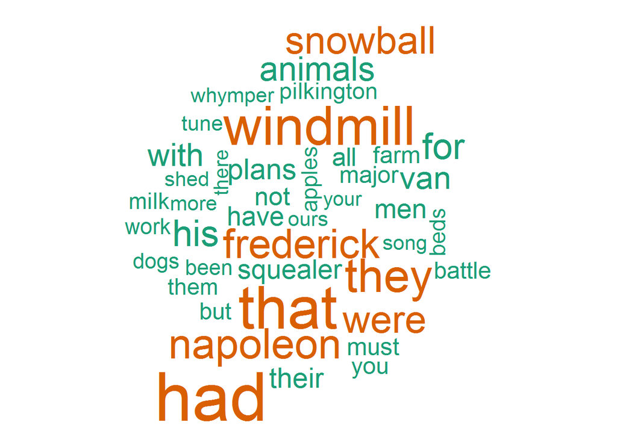

```r
library(wordcloud)
f <- sort(rowSums(docs.tfidf), decreasing = T)
docs.df <- data.frame(
  word = names(f),
  freq = f
)
wordcloud(docs.df$word, docs.df$freq, scale=c(20,0.1),min.freq=190,max.words=45, colors=brewer.pal(8, "Dark2"))
```

> 據文字雲的結果:

> 出現頻率高的是windmill,其為故事場所發生的重要地標，而snowball和napoleon為故事的重要主角。

# PCA (Principal components analysis, 主成份分析)

```r
docs.pca <- prcomp(docs.tfidf, scale = T)
```

## PCA 作圖

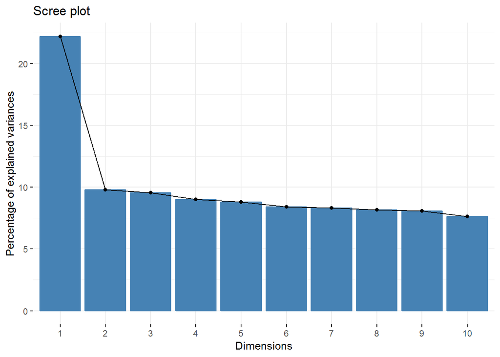

```r
fviz_eig(docs.pca)
```

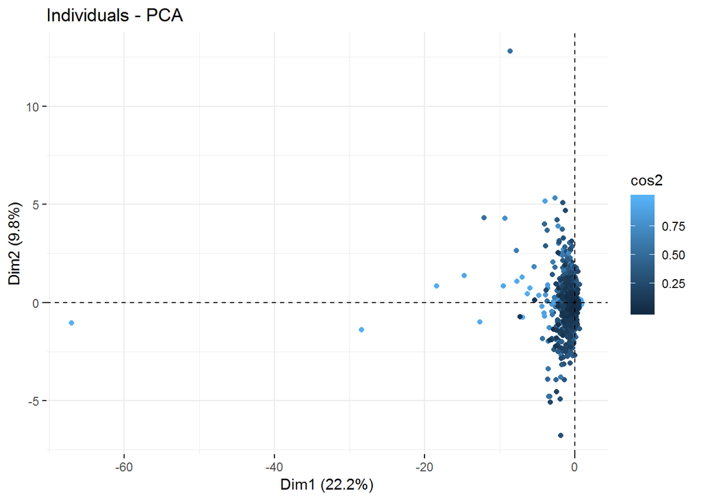

```r
fviz_pca_ind(docs.pca, geom.ind = c("point"), col.ind = "cos2")
```

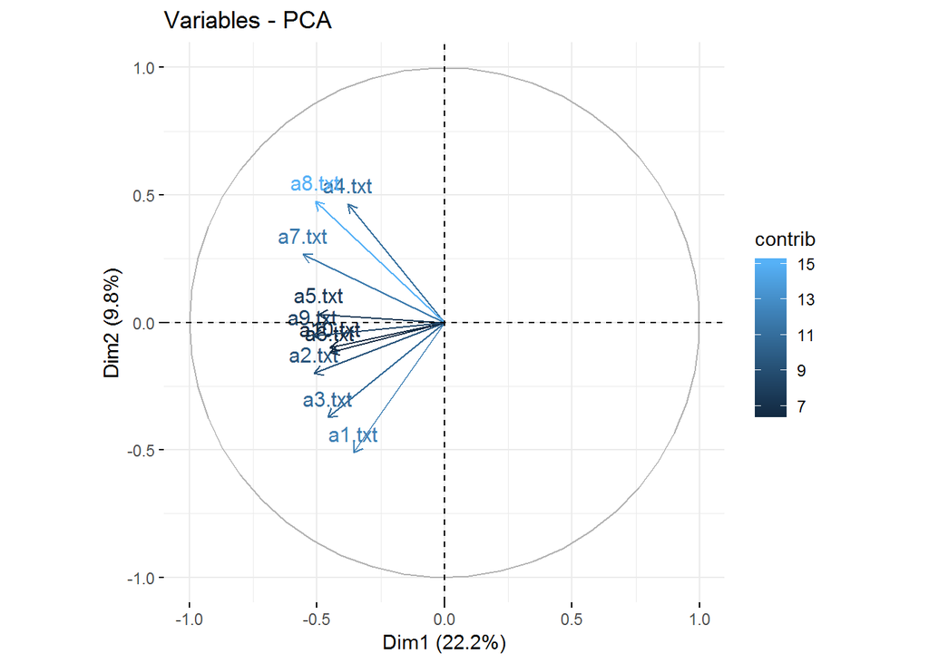

```r
fviz_pca_var(docs.pca, col.var = "contrib")
```

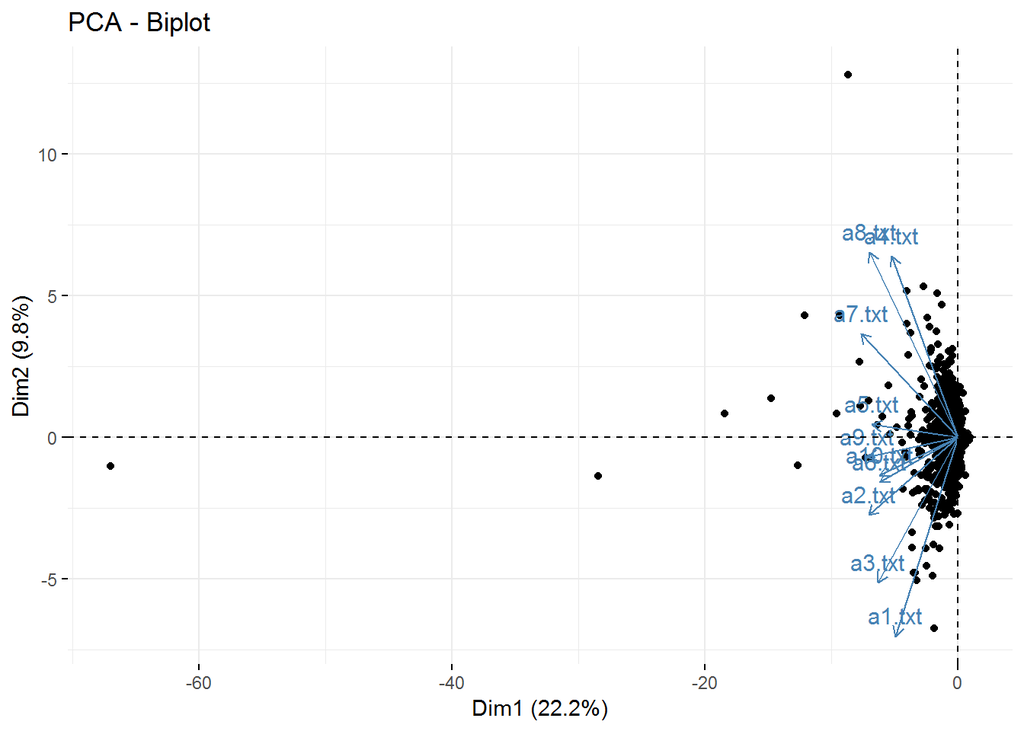

```r
fviz_pca_biplot(docs.pca, geom.ind = "point")
```

## PCA results

```r
docs.eig <- get_eig(docs.pca)
docs.var <- get_pca_var(docs.pca)
docs.ind <- get_pca_ind(docs.pca)
```

# K-means

## Choosing K

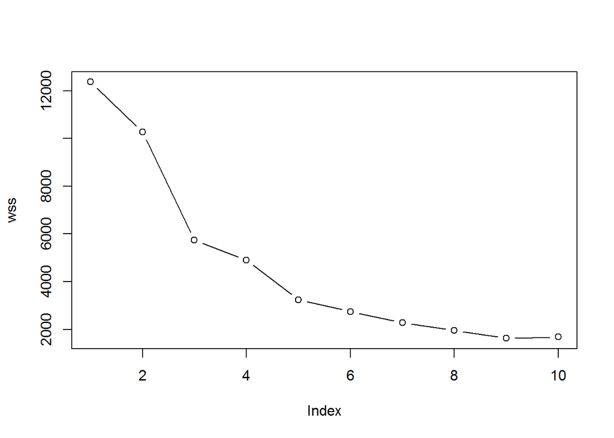

```r
ind.coord2 <- docs.ind$coord[, 1:2]
wss <- c()
for (i in 1:10) { wss[i] <- kmeans(ind.coord2, i)$tot.withinss }
plot(wss, type = "b")
```

## Clustering

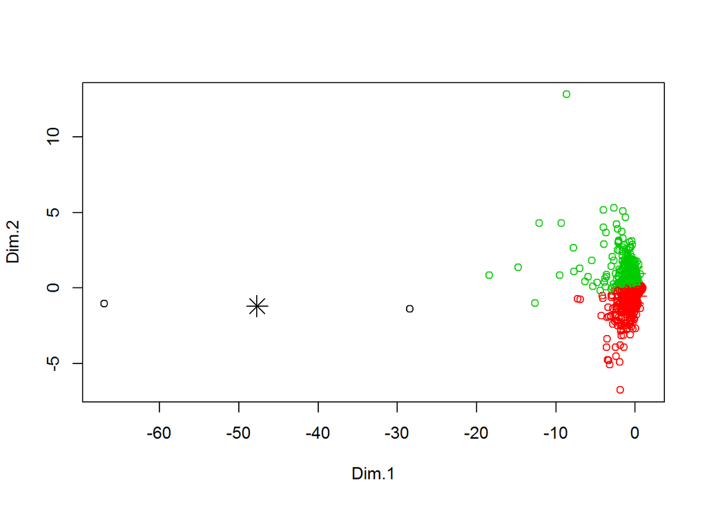

[figure not shown]

```r
km <- kmeans(ind.coord2, 3)
plot(ind.coord2, col = km$cluster)
points(km$centers, col = 1:50, pch = 8, cex = 2)
```